# Analysis of Variance: One-Way ANOVA

## Loading required R packages

- `multcomp`: `cholesterol` dataset
- `gplots`: The `plotmeans()` function can be used to produce a graph of group means and their confidence intervals
- `effects`: obtain adjusted group means-that is, the group means obtained after partialing out the effects of the covariate.
- `HH`: `ancova()` function provides a plot of the relationship between the dependent variable, the covariate, and the factor.

```
## lattice theme set by effectsTheme()
## See ?effectsTheme for details.
```

## One-Way ANOVA

### Cholesterol Example

`cholesterol` dataset in the `multcomp` package, and taken from Westfall, Tobia, Rom, & Hochberg (1999). Fifty patients received one of five cholesterol-reducing drug regiments (`trt`). Three of the treatment conditions involved the same drug administered as

- 20mg once per day (`1time`);
- 10mg twice per day (`2times`);
- 5mg four times per day (`4times`);
- The two remaining conditions (`drugD` and `drugE`) represented competing drugs.
- Which drug regimen produced the greatest cholesterol reduction (response)?

```r
# Load the data
library(multcomp)
attach(cholesterol)
# Group sample sizes
table(trt)
```

```
## trt
##  1time 2times 4times  drugD  drugE
##     10     10     10     10     10
```

```r
# Group means
aggregate(response, by=list(trt), FUN=mean)
```

```
##   Group.1        x
## 1   1time  5.78197
## 2  2times  9.22497
## 3  4times 12.37478
## 4   drugD 15.36117
## 5   drugE 20.94752
```

```r
# Group standard deviations
aggregate(response, by=list(trt), FUN=sd)
```

```
##   Group.1        x
## 1   1time 2.878113
## 2  2times 3.483054
## 3  4times 2.923119
## 4   drugD 3.454636
## 5   drugE 3.345003
```

```r
# Test for group differences (ANOVA)
fit <- aov(response ~ trt)
summary(fit)
```

```
##             Df Sum Sq Mean Sq F value   Pr(>F)
## trt          4 1351.4   337.8   32.43 9.82e-13 ***
## Residuals   45  468.8    10.4
## ---
## Signif. codes:  0 '***' 0.001 '**' 0.01 '*' 0.05 '.' 0.1 ' ' 1
```

Output Interpretation:

1. 10 patients received each of the drug regiments.
2. From the means, it appears that `drugE` produced the greatest cholesterol reduction, whereas `1time` produced the least.
3. Standard deviations were relatively constant across the five groups, ranging from 2.88 to 3.48.
4. The ANOVA F test for treatment (`trt`) is significant (p < .0001), providing evidence that the five treatments aren’t all equally effective.

The `plotmeans()` function in the `gplots` package can be used to produce a graph of group means and their confidence intervals. A plot of the treatment means, with 95 percent confidence limits, is provided in figure and allows you to clearly see these treatment differences.

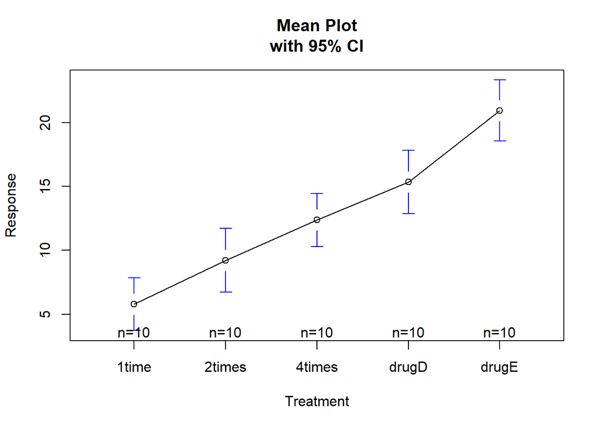

```r
library(gplots)
plotmeans(response ~ trt, xlab="Treatment", ylab="Response",
main="Mean Plot\nwith 95% CI")
```

### Multiple Comparisons

The ANOVA F test for treatment tells you that the five drug regiments aren’t equally effective, but it doesn’t tell you which treatments differ from one another.

You can use a multiple comparison procedure to answer this question. For example, the `TukeyHSD()` function provides a test of all pairwise differences between group means.

Note that the `TukeyHSD()` function has compatibility issues with package `HH` also used in this chapter; if `HH` is loaded, `TukeyHSD()` will fail. In that case, use `detach("package:HH")` to remove it from the search path and then call `TukeyHSD()`.

```r
TukeyHSD(fit)
```

```
##   Tukey multiple comparisons of means
##     95% family-wise confidence level
##
## Fit: aov(formula = response ~ trt)
##
## $trt
##                   diff        lwr       upr     p adj
## 2times-1time   3.44300 -0.6582817  7.544282 0.1380949
## 4times-1time   6.59281  2.4915283 10.694092 0.0003542
## drugD-1time    9.57920  5.4779183 13.680482 0.0000003
## drugE-1time   15.16555 11.0642683 19.266832 0.0000000
## 4times-2times  3.14981 -0.9514717  7.251092 0.2050382
## drugD-2times   6.13620  2.0349183 10.237482 0.0009611
## drugE-2times  11.72255  7.6212683 15.823832 0.0000000
## drugD-4times   2.98639 -1.1148917  7.087672 0.2512446
## drugE-4times   8.57274  4.4714583 12.674022 0.0000037
## drugE-drugD    5.58635  1.4850683  9.687632 0.0030633
```

Output Interpretation:

The mean cholesterol reductions for 1time and 2times aren’t significantly different from each other (p = 0.138), whereas the difference between 1time and 4times is significantly different (p < .001).

Pairwise comparisons:

- The first `par(las=2)` statement rotates the axis labels;
- The second `par(mar=c(5,8,4,2))` increases the left margin area so that the labels fit.
- In this graph, confidence intervals that include 0 indicate treatments that aren’t significantly different (p > 0.5).

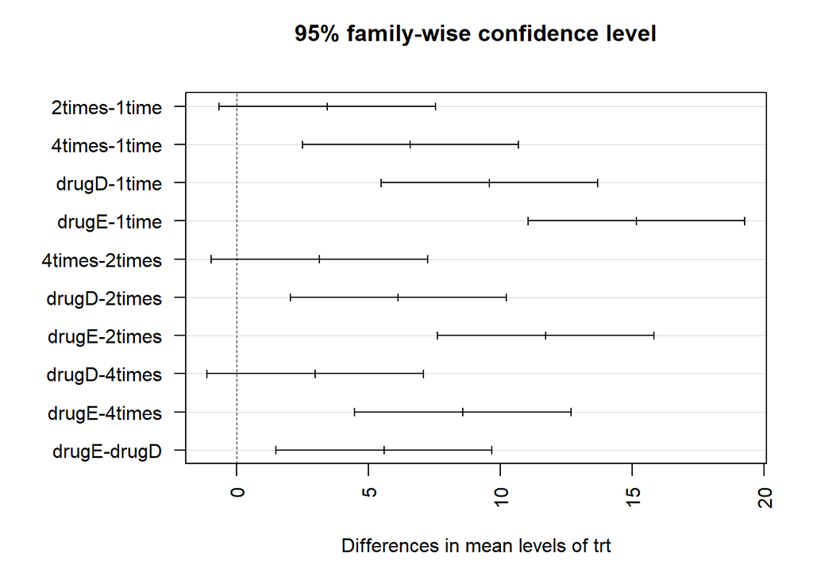

```r
par(las=2) # numeric in {0,1,2,3}; the style of axis labels.
par(mar=c(5,8,4,2)) # the number of lines of margin to be specified on the four sides of the plot
plot(TukeyHSD(fit))
```

The `glht()` function in the `multcomp` package provides a much more comprehensive set of methods for multiple mean comparisons that you can use for both linear models and generalized linear models.

- `glht()`: General linear hypotheses and multiple comparisons for parametric models;
- `cld()`: Extract information from `glht`. `level` provides the significance level to use.

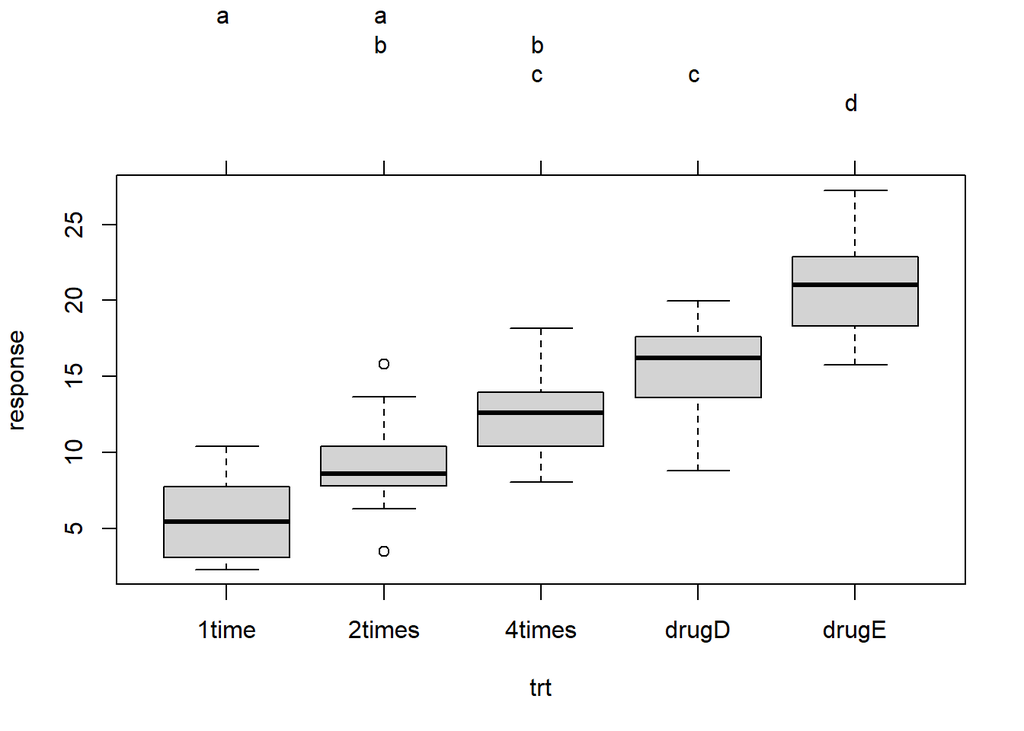

```r
library(multcomp)
par(mar=c(5,4,6,2))
tuk <- glht(fit, linfct=mcp(trt="Tukey"))
plot(cld(tuk, level=.05),col="lightgrey")
```

Output Interpretation: Groups (represented by box plots) that have the same letter don’t have significantly different means.

- `1time` and `2times` aren’t significantly different (they both have the letter a);
- `2times` and `4times` aren’t significantly different (they both have the letter b);
- `1time` and `4times` are different (they don’t share a letter).

In Summary:

- Taking the cholesterol-lowering drug in 5 mg doses four times a day `4times` was better than taking a 20 mg dose once per day `1time`.
- The competitor `drugD` wasn’t superior to this four-times-per-day regimen `4times`.
- The competitor `drugE` was superior to both `drugD` and all three dosage strategies for our focus drug.

## One-Way ANCOVA

A one-way analysis of covariance (ANCOVA) extends the one-way ANOVA to include one or more quantitative covariates.

### Litter Example

This example comes from the `litter` dataset in the `multcomp` package (see Westfall et al., 1999). Pregnant mice were divided into four treatment groups; each group received a different dose of a drug (0, 5, 50, or 500).

- The mean post-birth weight (`weight`) for each litter was the dependent variable.
- The dose of a drug (`dose`) was the independent variable.
- The gestation time (`gesttime`) was included as a covariate.

```r
data(litter, package="multcomp")
attach(litter)
table(dose)
```

```
## dose
##   0   5  50 500
##  20  19  18  17
```

```r
aggregate(weight, by=list(dose), FUN=mean)
```

```
##   Group.1        x
## 1       0 32.30850
## 2       5 29.30842
## 3      50 29.86611
## 4     500 29.64647
```

```r
fit1 <- aov(weight ~ gesttime + dose)
summary(fit1)
```

```
##             Df Sum Sq Mean Sq F value  Pr(>F)
## gesttime     1  134.3  134.30   8.049 0.00597 **
## dose         3  137.1   45.71   2.739 0.04988 *
## Residuals   69 1151.3   16.69
## ---
## Signif. codes:  0 '***' 0.001 '**' 0.01 '*' 0.05 '.' 0.1 ' ' 1
```

Output Interpretation:

- From the `table()` function you can see that there are an unequal number of litters at each dosage level, with 20 litters at zero dosage (no drug) and 17 litters at dosage 500.
- Based on the group means provided by the `aggregate()` function, the no-drug group had the highest mean litter weight (32.3).
- The ANCOVA F tests indicate that
  1. Gestation time was related to birth weight
  2. Drug dosage was related to birth weight after controlling for gestation time. The mean birth weight isn’t the same for each of the drug dosages, after controlling for gestation time.

Because you’re using a covariate, you may want to obtain adjusted group means-that is, the group means obtained after partialing out the effects of the covariate. You can use the `effect()` function in the `effects` library to calculate adjusted means:

```r
library(effects)
effect("dose", fit1)
```

```
##
##  dose effect
## dose
##        0        5       50      500
## 32.35367 28.87672 30.56614 29.33460
```

In this case, the adjusted means are similar to the unadjusted means produced by the `aggregate()` function, but this won’t always be the case. The effects package provides a powerful method of obtaining adjusted means for complex research designs and presenting them visually.

### Multiple Comparisons

As with the one-way ANOVA example in the last section, the F test for dose indicates that the treatments don’t have the same mean birth weight, but it doesn’t tell you which means differ from one another. Again you can use the multiple comparison procedures provided by the `multcomp` package to compute all pairwise mean comparisons.

```r
library(multcomp)
summary(glht(fit1, linfct=mcp(dose="Tukey")))
```

```
##
##   Simultaneous Tests for General Linear Hypotheses
##
## Multiple Comparisons of Means: Tukey Contrasts
##
##
## Fit: aov(formula = weight ~ gesttime + dose)
##
## Linear Hypotheses:
##               Estimate Std. Error t value Pr(>|t|)
## 5 - 0 == 0     -3.4769     1.3175  -2.639   0.0493 *
## 50 - 0 == 0    -1.7875     1.3437  -1.330   0.5468
## 500 - 0 == 0   -3.0191     1.3524  -2.232   0.1247
## 50 - 5 == 0     1.6894     1.3919   1.214   0.6201
## 500 - 5 == 0    0.4579     1.3642   0.336   0.9868
## 500 - 50 == 0  -1.2315     1.4192  -0.868   0.8213
## ---
## Signif. codes:  0 '***' 0.001 '**' 0.01 '*' 0.05 '.' 0.1 ' ' 1
## (Adjusted p values reported -- single-step method)
```

### Visualizing Results

The `ancova()` function in the `HH` package provides a plot of the relationship between the dependent variable, the covariate, and the factor.

```r
library(HH)
ancova(weight ~ gesttime + dose, data=litter)
```

```
## Analysis of Variance Table
##
## Response: weight
##           Df  Sum Sq Mean Sq F value   Pr(>F)
## gesttime   1  134.30 134.304  8.0493 0.005971 **
## dose       3  137.12  45.708  2.7394 0.049883 *
## Residuals 69 1151.27  16.685
## ---
## Signif. codes:  0 '***' 0.001 '**' 0.01 '*' 0.05 '.' 0.1 ' ' 1
```

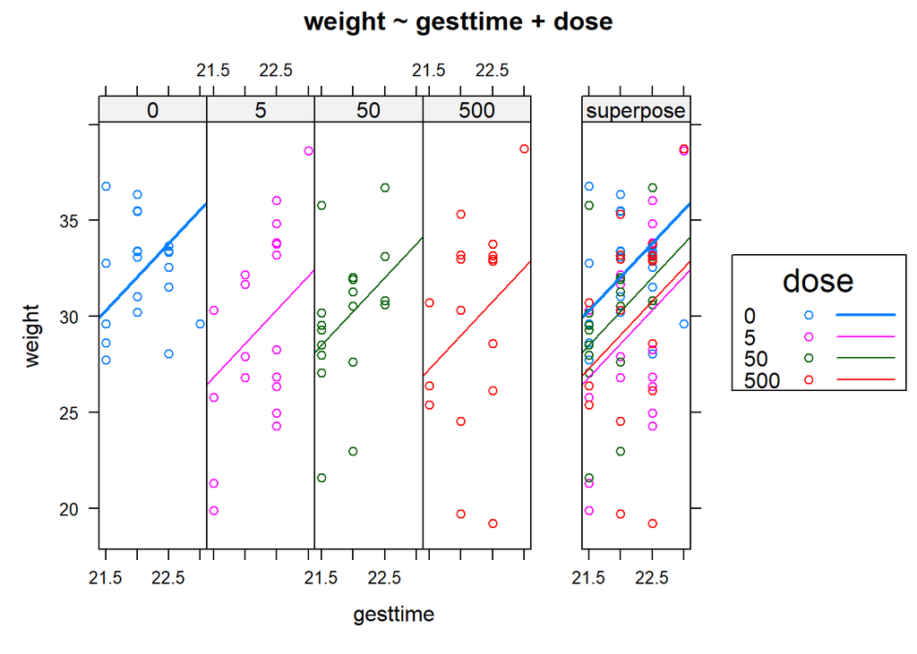

- Here you can see that the regression lines for predicting birth weight from gestation time are parallel in each group but have different intercepts. As gestation time increases, birth weight increases.
- You can see that the 0-dose group has the largest intercept and the 5-dose group has the lowest intercept.